# Prosper Loan Data Exploration

## by Dmitry Zmienko

## Investigation Overview

In this investigation, I planned to look what influence borrower's annual percentage rate (APR) and understand the Prosper company's lending policy.

## Dataset Overview

The dataset by company Prosper contains 113,937 loans with 81 variables on each loan from 2005 to 2014. For the purpose of the investigation I left only data afrom July 2009 (when Prosper issued their own rating system) and explore only group of variables:

1. Data that describes Listing: 'ListingKey', 'ListingCreationDate', 'Term', 'LoanStatus', 'BorrowerAPR', 'ProsperRating (Alpha)', 'ProsperScore', 'ListingCategory (numeric)'.
2. Data that describes Borrower: 'BorrowerState', 'Occupation', 'EmploymentStatus', 'IsBorrowerHomeowner', 'CreditScoreRangeLower', 'CreditScoreRangeUpper', 'IncomeRange', 'IncomeVerifiable', 'StatedMonthlyIncome'.
3. Data that describes Loan: 'TotalProsperLoans', 'LoanOriginalAmount', 'LoanOriginationDate', 'MonthlyLoanPayment', 'Recommendations'.

## Distribution of borrower's APR

Annual Percentage Rate (APR) is the interest charged for borrowing that represents the actual yearly cost of the loan expressed as a percentage. BorrowerAPR distribution looks normal (with the mean around 22%) except peak of around 36%. Most of the loans are in 10-36%

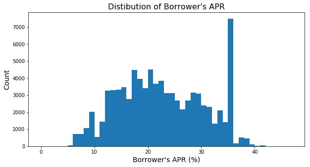

## Distribution of loan amount and term

Prosper company issues loans in a fairly narrow range from 1000 to 35000 for a period of 1, 3 or 5 years. The distribution of loan amount is skewed to the right, most of the borrowers take smaller loans. There is a spike at every 5000 dollar value which is most likely due to the fact that people obtain loans in rounded figure values.36 months is the most common loan period.

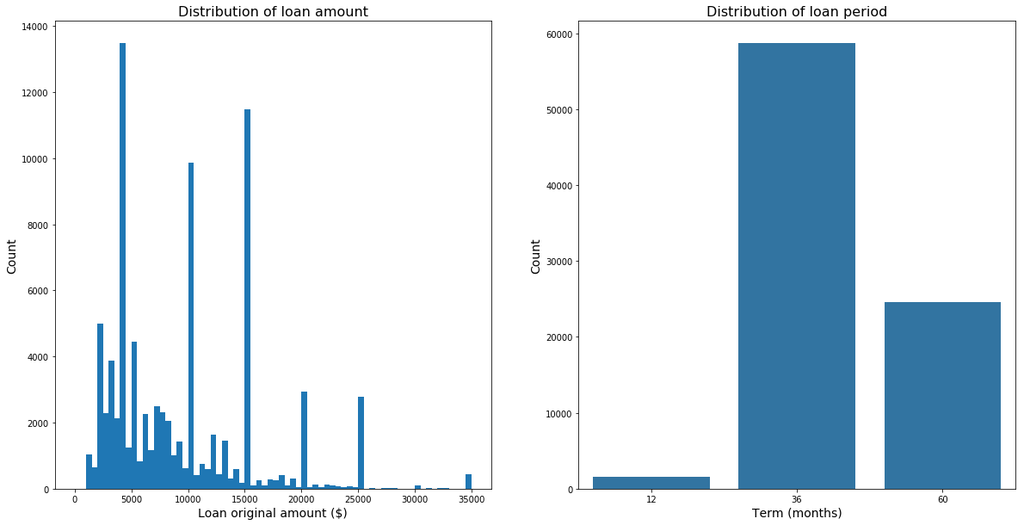

## Correlation between borrower's APR, his Prosper rating/Credit score and loan amount

Despite the fact that we see an almost direct relationship between the borrower's APR and the borrower's scores (Prosper's rating or Credit scores), we can argue that these values are not the only ones that determine the interest rate of a loan. On the top two charts, for each value, we see a wide range of APR values. Also, a significant impact on the borrower's APR is affected by the amount of the loan, but taking into account other factors, which we will discuss later.

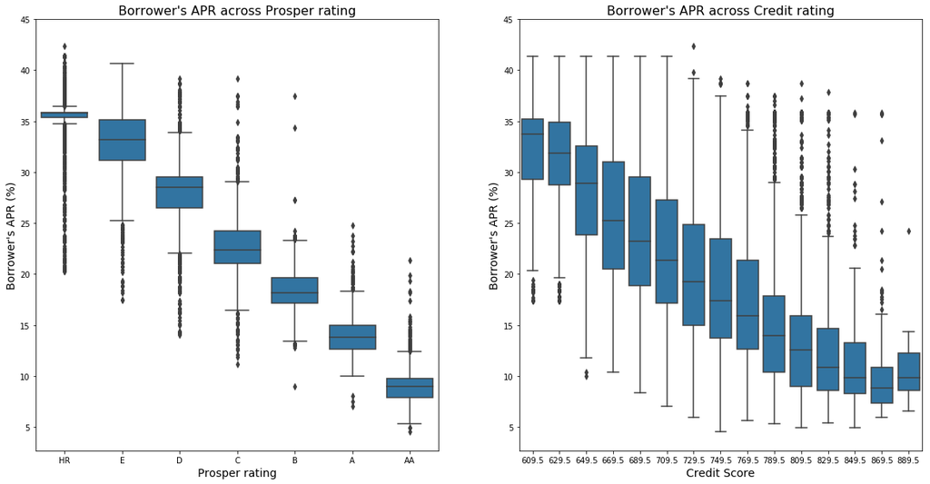

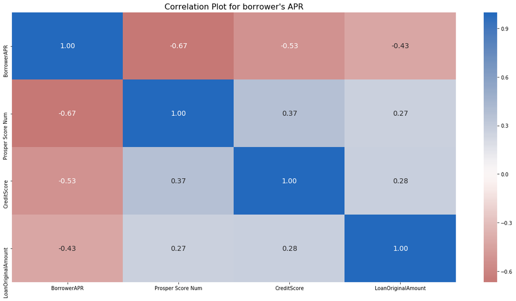

## Borrower's APR dependence on income

Looking only at the dependence of the borrower's APR on the income range, then, as expected, we will see that, for non-working and borrowers with lower income, the annual interest rate is higher. But if you look deeper into the distribution of monthly income, then despite a particular negative relationship between the borrower's APR and monthly income, we'll see that the spread of values is too large (for example, for monthly income more than $50K, most points are above a linear relationship). So the borrower's income weakly influences APR.

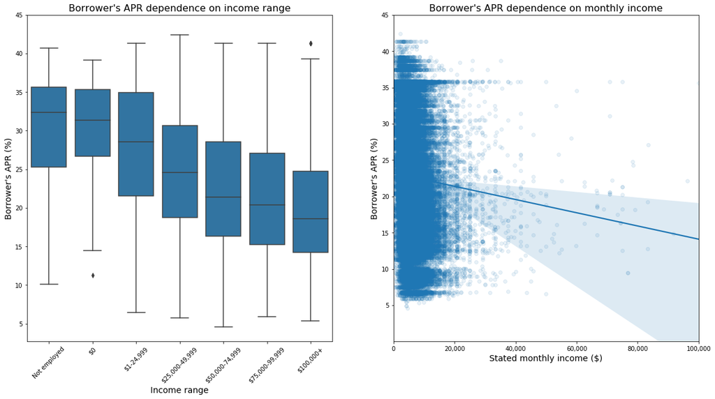

## Dependence of the borrower's APR on the Prosper rating and term

For lower ratings (E and HR), it's hard to get a loan for more than $10000, and the APR will be high (20-40%). For high-rated borrowers, we see that APR doesn't depend on the loan amount. But it is striking that for high-rated borrowers APR for bigger loans even increasing. On the contrary, the low-rated borrowers get lower APR for a bigger loan. Let's assume that this is due to company policy. Higher-ranked customers are more likely to be long-term and loyal to the brand (which is also confirmed by the higher APR for the credit rating of "890" compared to "870"). Customers with low ratings are primarily new clients, so the company is trying to attract them with a low APR.

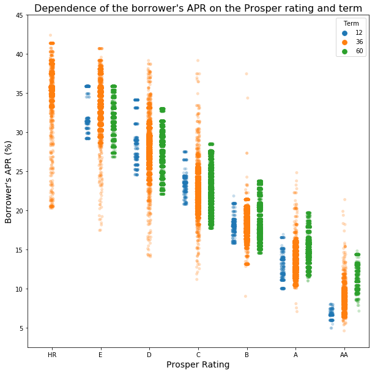

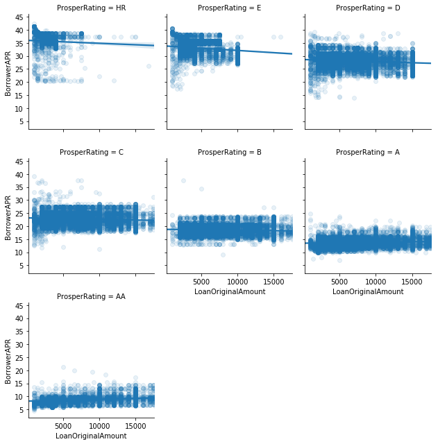

## How borrower's profile (empoyment status, home ownership, influence on borrower's APR?

Ownership of real estate reduces the risks for the lender. Same works for the employment status: employed borrowers tend to have lower APR. Highly qualified borrowers receive better loan offers. Loans for students for a technical school are allocated separately, a narrow spread of values shows that there is apparently some kind of specialized lending program for them.

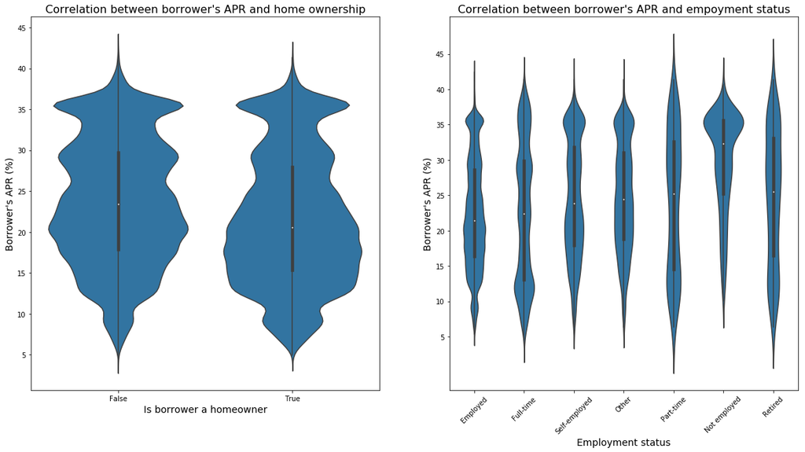

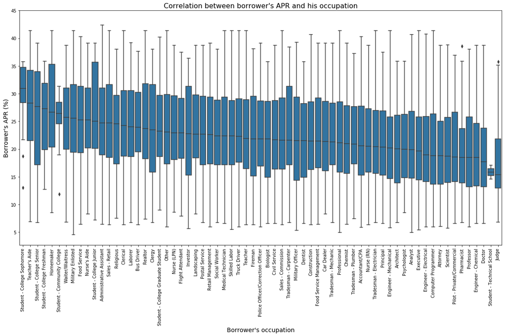